# Data Application Lab - Capstone Project #1: FinTech

Depei Zhang

07/26/2020

## 1. Introduction

### 1.1 Background

LendingClub [1] is an American peer-to-peer lending company, headquartered in San Francisco, California. It was the first peer-to-peer lender to register its offerings as securities with the Securities and Exchange Commission (SEC), and to offer loan trading on a secondary market. LendingClub is the world's largest peer-to-peer lending platform. The company claims that $15.98 billion in loans had been originated through its platform up to December 31, 2015. [2]

[1] https://www.lendingclub.com/

[2] https://en.wikipedia.org/wiki/LendingClub

### 1.2 Task & Purpose

The task of this project is to design an algorithm to select potentially high-return loans listed in lending club. To be specific, we will analyze the LendingClub's historical loan data, and use a machine learning model to predict whether or not one newly listed loan will be default in the future.

### 1.3 Metric & Evaluation

The 36-month term loan data from 2016Q1 to 2017Q2 will be used in this project, in which the loan data from 2016Q1 to 2017Q1 and the 2017Q2 data will be used as the training set and test set, respectively. The loan data will be trained based on some binary regression model, with the AUC, the area under the ROC curve, as the evaluation metric.

# 2. Data

### 2.1 Import LendingClub Data

```python
# load python library
import json
import requests
import datetime
import numpy as np
import seaborn as sns

import pandas as pd
pd.options.display.max_columns = None
pd.options.display.max_colwidth = None

import matplotlib.pyplot as plt
%matplotlib inline
```

#### 2.1.1 Import the current loan data

Use the LendingClub API: https://www.lendingclub.com/developers/api-overview

```python
# read api key
with open('apikey.txt', 'r') as file:
    api_key = file.read()

# send api request
r = requests.get('https://api.lendingclub.com/api/investor/v1/loans/listing', headers={'Authorization': api_key})

# extract data
data = r.json()

# convert to dataframe
df_curr = pd.json_normalize(data['loans'])

# show the dataframe
df_curr
```

|  | id | memberId | loanAmount | fundedAmount | term | intRate | expDefaultRate | serviceFeeRate | installment | grade | subGrade | empLength | homeOwnership | annualInc | isIncV | acceptD | expD | listD | creditPullD | reviewStatusD | reviewStatus | desc | purpose | addrZip | addrState | investorCount | ilsExpD | initialListStatus | empTitle | … |
| --- | --- | --- | --- | --- | --- | --- | --- | --- | --- | --- | --- | --- | --- | --- | --- | --- | --- | --- | --- | --- | --- | --- | --- | --- | --- | --- | --- | --- | --- | --- |
| 0 | 169531153 | 219835370 | 12000.0 | 3125.0 | 36 | 17.30 | 12.55 | 1.73 | 429.63 | C | C1 | 84.0 | RENT | 72000.0 | VERIFIED | 2020-07-31T04:14:57.000-07:00 | 2020-09-04T14:00:00.000-07:00 | 2020-08-05T14:00:00.000-07:00 | 2020-07-31T04:08:47.000-07:00 | 2020-08-05T11:43:22.000-07:00 | APPROVED | None | debt_consolidation | 368xx | AL | None | 2020-08-05T14:00:00.000-07:00 | F | Industrial Engineer | … |
| 1 | 169544378 | 219866708 | 5000.0 | 4100.0 | 36 | 19.12 | 12.55 | 1.73 | 183.59 | C | C3 | NaN | OWN | 23923.0 | VERIFIED | 2020-08-03T05:29:47.000-07:00 | 2020-09-04T14:00:00.000-07:00 | 2020-08-05T14:00:00.000-07:00 | 2020-08-03T05:27:22.000-07:00 | 2020-08-05T10:44:21.000-07:00 | APPROVED | None | debt_consolidation | 346xx | FL | None | 2020-08-05T14:00:00.000-07:00 | F | None | … |
| 2 | 169557636 | 219891067 | 2500.0 | 1700.0 | 36 | 15.40 | 9.43 | 1.53 | 87.16 | B | B4 | 48.0 | RENT | 22000.0 | VERIFIED | 2020-08-04T08:56:39.000-07:00 | 2020-09-04T14:00:00.000-07:00 | 2020-08-05T14:00:00.000-07:00 | 2020-08-04T08:46:27.000-07:00 | 2020-08-05T12:10:00.000-07:00 | APPROVED | None | debt_consolidation | 240xx | VA | None | 2020-08-05T14:00:00.000-07:00 | F | Quality Control Auditor | … |
| 3 | 169509349 | 219801423 | 5000.0 | 2900.0 | 36 | 17.30 | 12.55 | 1.73 | 179.02 | C | C1 | 24.0 | MORTGAGE | 98000.0 | SOURCE_VERIFIED | 2020-08-05T10:08:39.000-07:00 | 2020-09-04T14:00:00.000-07:00 | 2020-08-05T14:00:00.000-07:00 | 2020-07-28T14:46:35.000-07:00 | 2020-08-05T10:20:15.000-07:00 | APPROVED | None | home_improvement | 191xx | PA | None | 2020-08-05T14:00:00.000-07:00 | F | Sr. Business Analyst | … |
| 4 | 169541920 | 219878264 | 10000.0 | 5800.0 | 36 | 14.02 | 9.43 | 1.53 | 341.88 | B | B2 | 120.0 | MORTGAGE | 300000.0 | VERIFIED | 2020-08-03T11:35:51.000-07:00 | 2020-09-04T14:00:00.000-07:00 | 2020-08-05T14:00:00.000-07:00 | 2020-08-03T11:33:33.000-07:00 | 2020-08-05T10:41:47.000-07:00 | APPROVED | None | debt_consolidation | 017xx | MA | None | 2020-08-05T14:00:00.000-07:00 | F | VP Mergers and Acquisitions | … |
| 5 | 169567525 | 219970021 | 8500.0 | 2875.0 | 36 | 14.02 | 9.43 | 1.53 | 290.60 | B | B2 | 168.0 | MORTGAGE | 105000.0 | SOURCE_VERIFIED | 2020-08-05T11:09:29.000-07:00 | 2020-09-04T14:00:00.000-07:00 | 2020-08-05T14:00:00.000-07:00 | 2020-08-05T11:02:18.000-07:00 | 2020-08-05T11:12:21.000-07:00 | APPROVED | None | major_purchase | 495xx | MI | None | 2020-08-05T14:00:00.000-07:00 | F | Combo psc/hub | … |
| 6 | 169509358 | 219801433 | 11000.0 | 3525.0 | 36 | 10.19 | 4.67 | 1.28 | 355.93 | A | A4 | 180.0 | MORTGAGE | 67000.0 | VERIFIED | 2020-08-05T09:48:43.000-07:00 | 2020-09-04T14:00:00.000-07:00 | 2020-08-05T14:00:00.000-07:00 | 2020-07-28T15:07:48.000-07:00 | 2020-08-05T09:53:51.000-07:00 | APPROVED | None | major_purchase | 853xx | AZ | None | 2020-08-05T14:00:00.000-07:00 | F | Operation Supervisor | … |
| 7 | 169518112 | 219809261 | 20000.0 | 10475.0 | 60 | 17.30 | 11.84 | 1.60 | 500.29 | C | C1 | 120.0 | MORTGAGE | 75000.0 | VERIFIED | 2020-08-03T14:48:19.000-07:00 | 2020-09-04T14:00:00.000-07:00 | 2020-08-05T14:00:00.000-07:00 | 2020-07-29T10:24:12.000-07:00 | 2020-08-05T10:01:44.000-07:00 | APPROVED | None | home_improvement | 395xx | MS | None | 2020-08-05T14:00:00.000-07:00 | F | Chief | … |
| 8 | 169545561 | 219879865 | 15000.0 | 4700.0 | 60 | 17.30 | 11.84 | 1.60 | 375.22 | C | C1 | 12.0 | MORTGAGE | 150000.0 | NOT_VERIFIED | 2020-08-05T09:55:28.000-07:00 | 2020-09-04T14:00:00.000-07:00 | 2020-08-05T14:00:00.000-07:00 | 2020-08-03T07:11:53.000-07:00 | 2020-08-05T09:57:50.000-07:00 | APPROVED | None | home_improvement | 917xx | CA | None | 2020-08-05T14:00:00.000-07:00 | F | Mortgage loan officer | … |
| 9 | 169546579 | 219882878 | 18000.0 | 4825.0 | 36 | 13.33 | 9.43 | 1.53 | 609.36 | B | B1 | 12.0 | MORTGAGE | 49000.0 | VERIFIED | 2020-08-03T15:40:20.000-07:00 | 2020-09-04T14:00:00.000-07:00 | 2020-08-05T14:00:00.000-07:00 | 2020-08-03T08:13:57.000-07:00 | 2020-08-05T10:39:07.000-07:00 | APPROVED | None | debt_consolidation | 554xx | MN | None | 2020-08-05T14:00:00.000-07:00 | F | Mobile Equipment Specialist | … |
| 10 | 169545472 | 219868769 | 30000.0 | 5925.0 | 36 | 13.33 | 9.43 | 1.53 | 1015.60 | B | B1 | 60.0 | MORTGAGE | 100000.0 | VERIFIED | 2020-08-05T12:08:00.000-07:00 | 2020-09-04T14:00:00.000-07:00 | 2020-08-05T14:00:00.000-07:00 | 2020-08-03T06:13:27.000-07:00 | 2020-08-05T12:10:21.000-07:00 | APPROVED | None | debt_consolidation | 370xx | TN | None | 2020-08-05T14:00:00.000-07:00 | F | Nurse Manager | … |

#### 2.1.2 Import the historical loan data

Download from LendingClub website: https://www.lendingclub.com/info/download-data.action

- Use the 36-month term loans initiated in 2016Q1 - 2017Q2:
  - LoanStats_securev1_2016Q1.csv
  - LoanStats_securev1_2016Q2.csv
  - LoanStats_securev1_2016Q3.csv
  - LoanStats_securev1_2016Q4.csv
  - LoanStats_securev1_2017Q1.csv
  - LoanStats_securev1_2017Q2.csv

```python
# load all the quarterly data
quarter_list = ['2016Q1', '2016Q2', '2016Q3', '2016Q4', '2017Q1', '2017Q2']
df_list = {quarter : pd.read_csv('LoanStats_securev1_' + quarter + '.csv', skiprows=1, low_memory=False) for quarter in quarter_list}

# check if the columns are identical
assert(len(set([" ".join(df.columns) for df in df_list.values()])) == 1)

# merge all the quarters
df_hist = pd.concat([df[:-2] for df in df_list.values()], ignore_index=True)

# show the dataframe
df_hist
```

|  | id | member_id | loan_amnt | funded_amnt | funded_amnt_inv | term | int_rate | installment | grade | sub_grade | emp_title | emp_length | home_ownership | annual_inc | verification_status | issue_d | loan_status | pymnt_plan | url | desc | purpose | title | zip_code | addr_state | dti | delinq_2yrs | earliest_cr_line | fico_range_low | fico_range_high | … |
| --- | --- | --- | --- | --- | --- | --- | --- | --- | --- | --- | --- | --- | --- | --- | --- | --- | --- | --- | --- | --- | --- | --- | --- | --- | --- | --- | --- | --- | --- | --- |
| 0 | 75050380 | NaN | 10000.0 | 10000.0 | 10000.0 | 60 months | 13.67% | 230.98 | C | C3 | Deck | 9 years | MORTGAGE | 56000.0 | Verified | Mar-2016 | Current | n | https://lendingclub.com/browse/loanDetail.action?loan_id=75050380 | NaN | credit_card | NaN | 338xx | FL | 36.61 | 0.0 | Feb-1998 | 670.0 | 674.0 | … |
| 1 | 75358068 | NaN | 19000.0 | 19000.0 | 19000.0 | 36 months | 9.16% | 605.62 | B | B2 | Supervisor | 10+ years | RENT | 65000.0 | Source Verified | Mar-2016 | Fully Paid | n | https://lendingclub.com/browse/loanDetail.action?loan_id=75358068 | NaN | debt_consolidation | NaN | 917xx | CA | 16.36 | 1.0 | Feb-2001 | 670.0 | 674.0 | … |
| 2 | 75848321 | NaN | 10000.0 | 10000.0 | 10000.0 | 36 months | 7.89% | 312.86 | A | A5 | mechanic | 6 years | MORTGAGE | 58000.0 | Source Verified | Mar-2016 | Fully Paid | n | https://lendingclub.com/browse/loanDetail.action?loan_id=75848321 | NaN | credit_card | Credit card refinancing | 327xx | FL | 5.03 | 0.0 | Feb-2012 | 690.0 | 694.0 | … |
| 3 | 75909983 | NaN | 6000.0 | 6000.0 | 6000.0 | 36 months | 11.47% | 197.78 | B | B5 | Clerk Typist III | 10+ years | RENT | 46900.0 | Source Verified | Mar-2016 | Fully Paid | n | https://lendingclub.com/browse/loanDetail.action?loan_id=75909983 | NaN | credit_card | Credit card refinancing | 553xx | MN | 24.23 | 2.0 | Aug-1994 | 665.0 | 669.0 | … |
| 4 | 75931689 | NaN | 35000.0 | 35000.0 | 35000.0 | 60 months | 11.47% | 769.22 | B | B5 | Controls Engineer | 4 years | MORTGAGE | 137000.0 | Verified | Mar-2016 | Fully Paid | n | https://lendingclub.com/browse/loanDetail.action?loan_id=75931689 | NaN | credit_card | Credit card refinancing | 775xx | TX | 30.17 | 1.0 | May-2001 | 700.0 | 704.0 | … |
| ... | ... | ... | ... | ... | ... | ... | ... | ... | ... | ... | ... | ... | ... | ... | ... | ... | ... | ... | ... | ... | ... | ... | ... | ... | ... | ... | ... | ... | ... | … |
| 636632 | 102556443 | NaN | 24000.0 | 24000.0 | 24000.0 | 60 months | 23.99% | 690.30 | E | E2 | Senior Escrow Officer | < 1 year | RENT | 107000.0 | Source Verified | Apr-2017 | Charged Off | n | https://lendingclub.com/browse/loanDetail.action?loan_id=102556443 | NaN | other | Other | 801xx | CO | 11.65 | 3.0 | Apr-1995 | 670.0 | 674.0 | … |
| 636633 | 102653304 | NaN | 10000.0 | 10000.0 | 10000.0 | 36 months | 7.99% | 313.32 | A | A5 | Rn | 10+ years | MORTGAGE | 65000.0 | Source Verified | Apr-2017 | Fully Paid | n | https://lendingclub.com/browse/loanDetail.action?loan_id=102653304 | NaN | debt_consolidation | Debt consolidation | 187xx | PA | 19.55 | 1.0 | Sep-1993 | 725.0 | 729.0 | … |
| 636634 | 102628603 | NaN | 10050.0 | 10050.0 | 10050.0 | 36 months | 16.99% | 358.26 | D | D1 | Sales Associate | 8 years | RENT | 37000.0 | Not Verified | Apr-2017 | Charged Off | n | https://lendingclub.com/browse/loanDetail.action?loan_id=102628603 | NaN | debt_consolidation | Debt consolidation | 220xx | VA | 20.56 | 0.0 | May-1993 | 705.0 | 709.0 | … |
| 636635 | 102196576 | NaN | 6000.0 | 6000.0 | 6000.0 | 36 months | 11.44% | 197.69 | B | B4 | Contact input | 5 years | RENT | 41000.0 | Source Verified | Apr-2017 | Fully Paid | n | https://lendingclub.com/browse/loanDetail.action?loan_id=102196576 | NaN | credit_card | Credit card refinancing | 105xx | NY | 19.99 | 1.0 | May-1990 | 670.0 | 674.0 | … |
| 636636 | 99799684 | NaN | 30000.0 | 30000.0 | 30000.0 | 60 months | 25.49% | 889.18 | E | E4 | Assistant Manager | 4 years | MORTGAGE | 105700.0 | Verified | Apr-2017 | Charged Off | n | https://lendingclub.com/browse/loanDetail.action?loan_id=99799684 | NaN | debt_consolidation | Debt consolidation | 797xx | TX | 27.26 | 1.0 | Nov-1997 | 695.0 | 699.0 | … |

636637 rows × 150 columns

### 2.2 Feature Name Format Conversion

The feature names in the current & historical data are different, so we need to do some format conversion and extract the common features for the further analysis.

```python
# get feature names for the current data, and convert to lower case
col_curr = list(df_curr.columns.values)
col_curr = [col.lower() for col in col_curr]

# get feature names for the historical data, and remove the underscore symbol
col_hist = list(df_hist.columns.values)
col_hist = [col.replace('_', '') for col in col_hist]

# extract the common & unique features
col_comm = list(set(col_curr) & set(col_hist))
col_curr_uni = list(set(col_curr) - set(col_hist))
col_hist_uni = list(set(col_hist) - set(col_curr))

# list the results
print(f"Common features: {len(col_comm)}\n{col_comm}\n")
print(f"df_curr unique features: {len(col_curr_uni)}\n{col_curr_uni}\n")
print(f"df_hist unique features: {len(col_hist_uni)}\n{col_hist_uni}\n")
```

```
Common features: 100
['accnowdelinq', 'mthssincelastrecord', 'secapprevolutil', 'openil12m', 'inqlast12m', 'pubrec', 'openil24m', 'ficorangehigh', 'percentbcgt75', 'secappmthssincelastmajorderog', 'annualincjoint', 'numtloppast12m', 'emplength', 'totcurbal', 'intrate', 'totalacc', 'pcttlnvrdlq', 'numbcsats', 'mthssincer…

df_curr unique features: 19
['acceptd', 'mtgpayment', 'servicefeerate', 'listd', 'expd', 'loanamount', 'fundedamount', 'reviewstatusd', 'numacctsever120ppd', 'investorcount', 'addrzip', 'ilsexpd', 'isincv', 'disbursementmethod', 'housingpayment', 'reviewstatus', 'expdefaultrate', 'creditpulld', 'isincvjoint']

df_hist unique features: 50
['collectionrecoveryfee', 'outprncpinv', 'origprojectedadditionalaccruedinterest', 'totalreclatefee', 'hardshipflag', 'settlementdate', 'hardshipstartdate', 'hardshiptype', 'zipcode', 'lastcreditpulld', 'hardshippayoffbalanceamount', 'settlementterm', 'loanstatus', 'loanamnt', 'hardshipamount', 'iss…
```

```python
# read the column descriptions
# Current data: https://www.lendingclub.com/developers/listed-loans
df_col_curr = pd.read_excel('ListedLoans.xlsx', sheet_name=0)
df_col_curr = df_col_curr[:-2]

# Historical data: https://resources.lendingclub.com/LCDataDictionary.xlsx
df_col_hist = pd.read_excel('LCDataDictionary.xlsx', sheet_name=0)
df_col_hist = df_col_hist[:-2]

# format conversion
df_col_curr['Name'] = df_col_curr['Name'].map(lambda x : str(x).lower().replace('_', ''))
df_col_hist['LoanStatNew'] = df_col_hist['LoanStatNew'].map(lambda x : str(x).replace('_', ''))

# convert to dict
desc_curr = df_col_curr.set_index('Name')['Description'].to_dict()
desc_hist = df_col_hist.set_index('LoanStatNew')['Description'].to_dict()

# show data
print(f"current feature description:\n{desc_curr}\n")
print(f"historical feature description:\n{desc_hist}\n")
```

```
current feature description:
{'asofdate': 'As of date', 'id': 'A unique LC assigned ID for the loan listing.', 'memberid': 'A unique LC assigned Id for the borrower member.', 'term': 'The Number of payments on the loan. Values are in months and can be either 36 or 60.', 'intrate': 'Interest Rate on the loan', 'expdefaultrate': …

historical feature description:
{'accnowdelinq': 'The number of accounts on which the borrower is now delinquent.', 'accopenpast24mths': 'Number of trades opened in past 24 months.', 'addrstate': 'The state provided by the borrower in the loan application', 'allutil': 'Balance to credit limit on all trades', 'annualinc': 'The self…
```

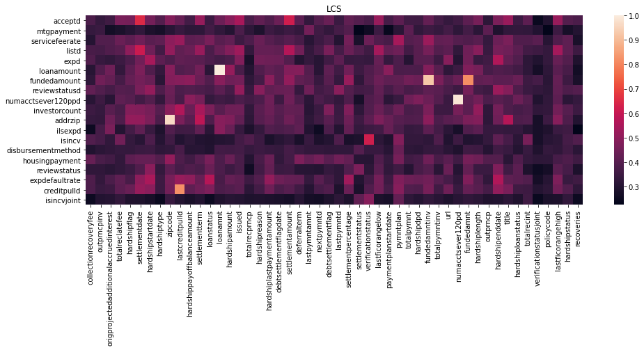

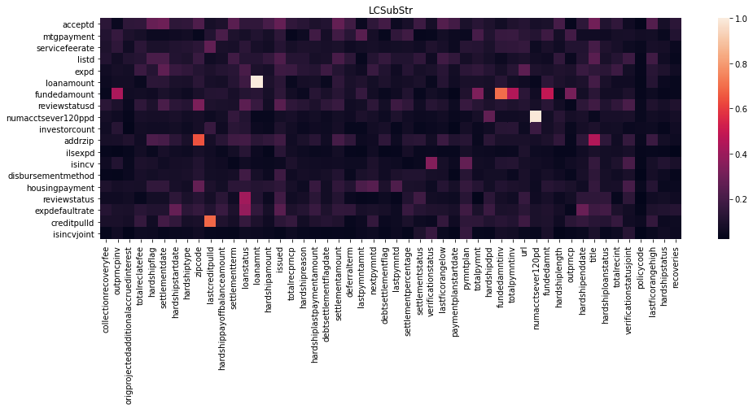

```python
# descriptions for unique features
desc_curr_uni = [desc_curr.get(col, col) for col in col_curr_uni]
desc_hist_uni = [desc_hist.get(col, col) for col in col_hist_uni]



# use two algorithms to compare the descriptions:
# 1. Longest Common Subsequence (LCS)
# 2. Longest Common Substring (LCSubStr)

# Dynamic Programming implementation of LCS problem
# https://www.geeksforgeeks.org/python-program-for-longest-common-subsequence/
def lcs(X, Y):
    # find the length of the strings
    m = len(X)
    n = len(Y)

    # declaring the array for storing the dp values
    L = [[None]*(n+1) for i in range(m+1)]

    """Following steps build L[m+1][n+1] in bottom up fashion
    Note: L[i][j] contains length of LCS of X[0..i-1]
    and Y[0..j-1]"""

    for i in range(m+1):
        for j in range(n+1):
            if i == 0 or j == 0:
                L[i][j] = 0
            elif X[i-1] == Y[j-1]:
                L[i][j] = L[i-1][j-1]+1
            else:
                L[i][j] = max(L[i-1][j] , L[i][j-1])

    # L[m][n] contains the length of LCS of X[0..n-1] & Y[0..m-1]
    return L[m][n]

# Finding Length of Longest Common Substring
# https://www.geeksforgeeks.org/longest-common-substring-dp-29/
# substring of X[0..m-1] and Y[0..n-1]
def LCSubStr(X, Y, m=-1, n=-1):
    if m == -1:
        m = len(X)
    if n == -1:
        n = len(Y)

    # Create a table to store lengths of
    # longest common suffixes of substrings.
    # Note that LCSuff[i][j] contains the
    # length of longest common suffix of
    # X[0...i-1] and Y[0...j-1]. The first
    # row and first column entries have no
    # logical meaning, they are used only
    # for simplicity of the program.

    # LCSuff is the table with zero
    # value initially in each cell
    LCSuff = [[0 for k in range(n+1)] for l in range(m+1)]

    # To store the length of
    # longest common substring
    result = 0

    # Following steps to build
    # LCSuff[m+1][n+1] in bottom up fashion
    for i in range(m + 1):
        for j in range(n + 1):
            if (i == 0 or j == 0):
                LCSuff[i][j] = 0
            elif (X[i-1] == Y[j-1]):
                LCSuff[i][j] = LCSuff[i-1][j-1] + 1
                result = max(result, LCSuff[i][j])
            else:
                LCSuff[i][j] = 0
    return result


# LCS score
col_lcs = [[lcs(col1, col2) / np.sqrt(len(col1) * len(col2)) for col2 in desc_hist_uni] for col1 in desc_curr_uni]
df_lcs = pd.DataFrame(np.array(col_lcs), index=col_curr_uni, columns=col_hist_uni)

# show heatmap
plt.figure(figsize=(16, 5))
plt.title('LCS')
sns.heatmap(df_lcs)
plt.show()

# LCSubStr score
col_lcss = [[LCSubStr(col1, col2) / np.sqrt(len(col1) * len(col2)) for col2 in desc_hist_uni] for col1 in desc_curr_uni]
df_lcss = pd.DataFrame(np.array(col_lcss), index=col_curr_uni, columns=col_hist_uni)

# show heatmap
plt.figure(figsize=(16, 5))
plt.title('LCSubStr')
sns.heatmap(df_lcss)
plt.show()
```

From the LCS & LCSubStr analysis, we observe the following current feature -> history feature correspondence:

- addrzip -> zipcode
- loanamount -> loanamnt
- fundedamount -> fundedamnt
- numacctsever120ppd -> numacctsever120pd

Two additional pairs discovered through comparing the dataframes and desciptions:

- isincv -> verificationstatus
- isincvjoint -> verificationstatusjoint

```python
# mapping from current features to historical features
map_curr2hist = {
    'addrzip' : 'zipcode',
    'loanamount' : 'loanamnt',
    'fundedamount' : 'fundedamnt',
    'numacctsever120ppd' : 'numacctsever120pd',
    'isincv' : 'verificationstatus',
    'isincvjoint' : 'verificationstatusjoint',
}
```

```python
# add common features that have different names for current and historical data
# use the form in the historical data
common_feature = list(set(col_comm) | set(map_curr2hist.values()))

# print common features
print(f"common features: {len(common_feature)}\n{common_feature}\n")
```

```
common features: 106
['totalilhighcreditlimit', 'numactvrevtl', 'accnowdelinq', 'mthssincelastrecord', 'secapprevolutil', 'ficorangelow', 'openil12m', 'mosinoldrevtlop', 'zipcode', 'openrv12m', 'inqlast12m', 'pubrec', 'loanamnt', 'openil24m', 'ficorangehigh', 'percentbcgt75', 'secappmthssincelastmajorderog', 'annualincj…
```

```python
# convert historical dataframe
df_hist_comm = df_hist.rename(columns=lambda x : str(x).replace('_',''))

# use the common features & issued date for traing test splitting, loan status for target
df_hist_comm = df_hist_comm[common_feature + ['issued', 'loanstatus']]

# save dataframe
df_hist_comm.to_csv('loan_hist.csv', index=False)

# show dataframe
df_hist_comm
```

|  | totalilhighcreditlimit | numactvrevtl | accnowdelinq | mthssincelastrecord | secapprevolutil | ficorangelow | openil12m | mosinoldrevtlop | zipcode | openrv12m | inqlast12m | pubrec | loanamnt | openil24m | ficorangehigh | percentbcgt75 | secappmthssincelastmajorderog | annualincjoint | numtloppast12m | bcutil | bcopentobuy | earliestcrline | tothicredlim | emplength | totcurbal | intrate | numiltl | secappnumrevaccts | mthssincerecentrevoldelinq | … |
| --- | --- | --- | --- | --- | --- | --- | --- | --- | --- | --- | --- | --- | --- | --- | --- | --- | --- | --- | --- | --- | --- | --- | --- | --- | --- | --- | --- | --- | --- | --- |
| 0 | 92703.0 | 5.0 | 0.0 | NaN | NaN | 670.0 | 0.0 | 217.0 | 338xx | 2.0 | 2.0 | 0.0 | 10000.0 | 3.0 | 674.0 | 50.0 | NaN | NaN | 3.0 | 32.3 | 7316.0 | Feb-1998 | 236712.0 | 9 years | 185350.0 | 13.67% | 10.0 | NaN | 69.0 | … |
| 1 | 28487.0 | 4.0 | 0.0 | NaN | NaN | 670.0 | 1.0 | 181.0 | 917xx | 0.0 | 0.0 | 0.0 | 19000.0 | 4.0 | 674.0 | 0.0 | NaN | NaN | 1.0 | 0.0 | 1600.0 | Feb-2001 | 43387.0 | 10+ years | 33375.0 | 9.16% | 13.0 | NaN | 12.0 | … |
| 2 | 0.0 | 3.0 | 0.0 | NaN | NaN | 690.0 | 0.0 | 49.0 | 327xx | 1.0 | 1.0 | 0.0 | 10000.0 | 0.0 | 694.0 | 100.0 | NaN | NaN | 1.0 | 87.4 | 629.0 | Feb-2012 | 156475.0 | 6 years | 151309.0 | 7.89% | 1.0 | NaN | NaN | … |
| 3 | 29162.0 | 4.0 | 0.0 | NaN | NaN | 665.0 | 1.0 | 140.0 | 553xx | 1.0 | 1.0 | 0.0 | 6000.0 | 1.0 | 669.0 | 33.3 | NaN | NaN | 2.0 | 36.2 | 5929.0 | Aug-1994 | 45362.0 | 10+ years | 19337.0 | 11.47% | 6.0 | NaN | 4.0 | … |
| 4 | 173688.0 | 7.0 | 0.0 | NaN | NaN | 700.0 | 0.0 | 178.0 | 775xx | 0.0 | 0.0 | 0.0 | 35000.0 | 1.0 | 704.0 | 50.0 | NaN | NaN | 0.0 | 85.0 | 9475.0 | May-2001 | 480143.0 | 4 years | 407769.0 | 11.47% | 11.0 | NaN | 28.0 | … |
| ... | ... | ... | ... | ... | ... | ... | ... | ... | ... | ... | ... | ... | ... | ... | ... | ... | ... | ... | ... | ... | ... | ... | ... | ... | ... | ... | ... | ... | ... | … |
| 636632 | 64422.0 | 7.0 | 0.0 | 73.0 | NaN | 670.0 | 1.0 | 263.0 | 801xx | 1.0 | 2.0 | 2.0 | 24000.0 | 3.0 | 674.0 | 0.0 | NaN | NaN | 2.0 | 26.0 | 20859.0 | Apr-1995 | 103322.0 | < 1 year | 60812.0 | 23.99% | 5.0 | NaN | 4.0 | … |
| 636633 | 70203.0 | 8.0 | 0.0 | NaN | NaN | 725.0 | 0.0 | 282.0 | 187xx | 2.0 | 0.0 | 0.0 | 10000.0 | 0.0 | 729.0 | 14.3 | NaN | NaN | 2.0 | 24.6 | 26229.0 | Sep-1993 | 132303.0 | 10+ years | 55863.0 | 7.99% | 4.0 | NaN | 12.0 | … |
| 636634 | 0.0 | 13.0 | 0.0 | NaN | NaN | 705.0 | 0.0 | 286.0 | 220xx | 5.0 | 1.0 | 0.0 | 10050.0 | 0.0 | 709.0 | 0.0 | NaN | NaN | 5.0 | 66.1 | 3054.0 | May-1993 | 30400.0 | 8 years | 14300.0 | 16.99% | 3.0 | NaN | 65.0 | … |
| 636635 | 34076.0 | 3.0 | 1.0 | NaN | NaN | 670.0 | 1.0 | 322.0 | 105xx | 0.0 | 3.0 | 0.0 | 6000.0 | 2.0 | 674.0 | 0.0 | NaN | NaN | 1.0 | 5.5 | 7651.0 | May-1990 | 47476.0 | 5 years | 26201.0 | 11.44% | 9.0 | NaN | 0.0 | … |
| 636636 | 89732.0 | 4.0 | 0.0 | NaN | NaN | 695.0 | 0.0 | 232.0 | 797xx | 0.0 | 1.0 | 0.0 | 30000.0 | 2.0 | 699.0 | 66.7 | NaN | NaN | 1.0 | 80.6 | 3107.0 | Nov-1997 | 275706.0 | 4 years | 239458.0 | 25.49% | 11.0 | NaN | 6.0 | … |

636637 rows × 108 columns

### 2.3 Exploratory Data Analysis

```python
# copy dataframe
df = df_hist_comm.copy()

# only use data with term = ' 36 months' and loanstatus = 'Fully Paid' or 'Charged Off'
df = df.query("term == ' 36 months'").query("loanstatus == 'Fully Paid' or loanstatus == 'Charged Off'")
df.reset_index(drop=True, inplace=True)
```

```python
# separate null, numerical & categorical features
null_feature=[]
num_feature=[]
cat_feature=[]
for col in df.columns.values:
    if df[col].isnull().sum() >= df.shape[0] * 0.98 or df[col].unique().size == 1:
        null_feature.append(col)
    elif df[col].dtype == 'object':
        cat_feature.append(col)
    else:
        num_feature.append(col)

# print results
print(f'null feature : {len(null_feature)}')
print(f'numerical feature : {len(num_feature)}')
print(f'categorical feature : {len(cat_feature)}')
```

```
null feature : 16
numerical feature : 74
categorical feature : 18
```

#### 2.3.1 Explore categorical features

```
112xx    5126
945xx    4907
750xx    4852
606xx    4529
300xx    4158
         ...
555xx       1
528xx       1
909xx       1
353xx       1
009xx       1
Name: zipcode, Length: 907, dtype: int64

Sep-2004    3532
Sep-2005    3502
Sep-2003    3417
Aug-2003    3391
Aug-2004    3360
            ...
Mar-1955       1
Dec-1946       1
Oct-1960       1
Feb-1934       1
Jan-1953       1
Name: earliestcrline, Length: 678, dtype: int64

  5.32%    26790
 11.49%    26218
 13.49%    16804
 10.49%    15366
 13.99%    15277
           ...
 17.86%        1
 21.99%        1
 25.99%        1
 11.16%        1
 22.99%        1
Name: intrate, Length: 167, dtype: int64

0%        2123
```

[output cut: 22 more lines]

```
105293580    1
Name: id, Length: 467989, dtype: int64

Teacher                      8853
Manager                      7931
Owner                        5880
Driver                       3691
Registered Nurse             3561
                             ...
Driver of Hazard (HazMat)       1
traveling operator              1
System Anayst                   1
Staff assistant                 1
EWIII                           1
Name: emptitle, Length: 126369, dtype: int64
```

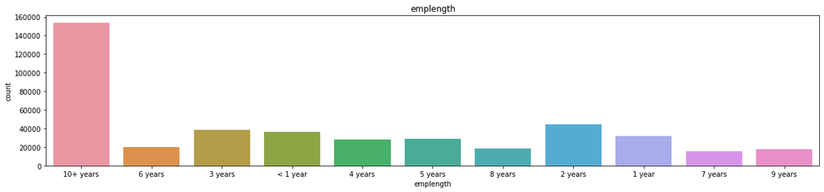

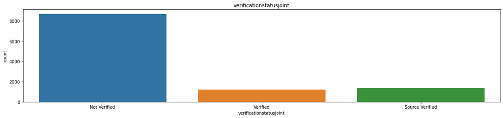

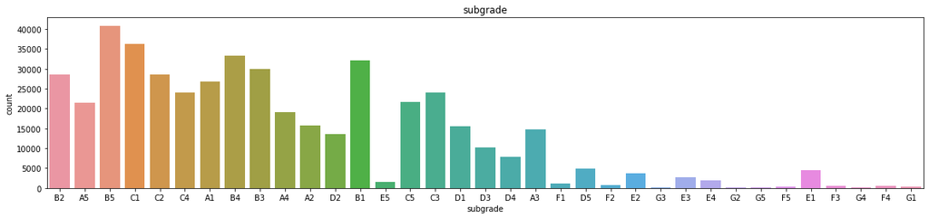

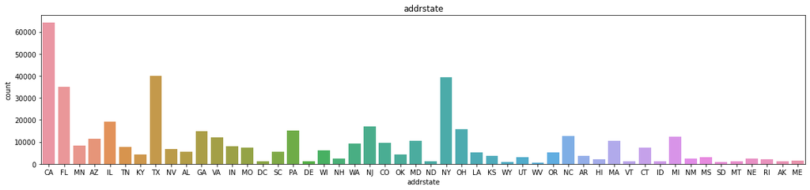

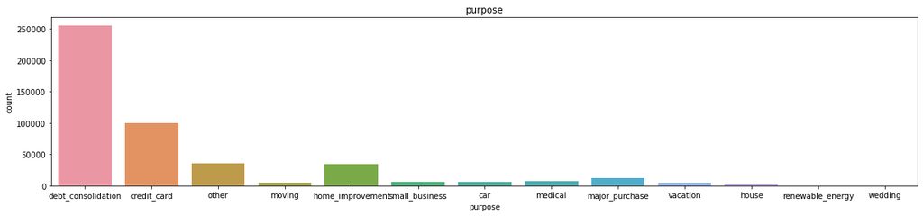

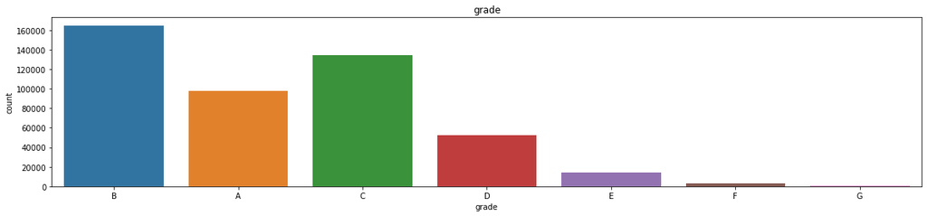

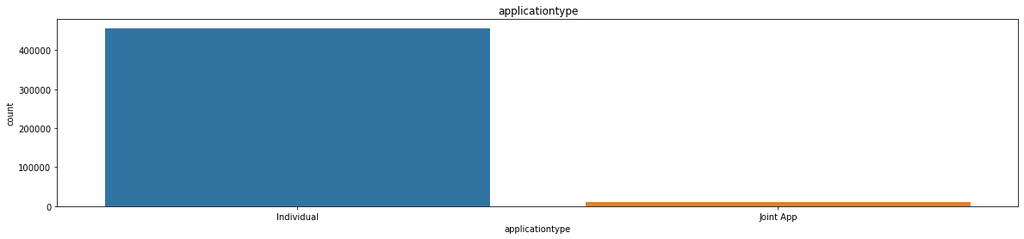

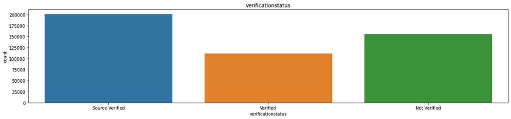

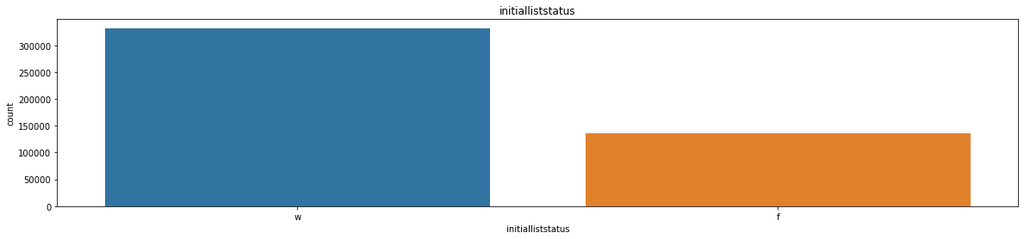

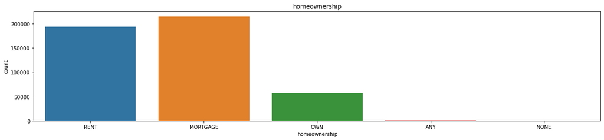

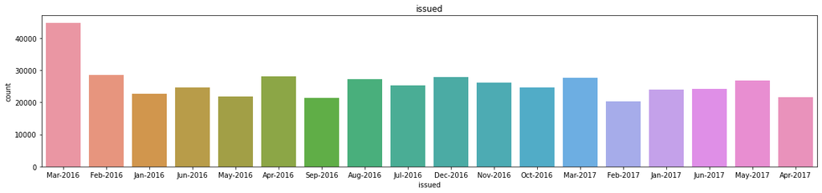

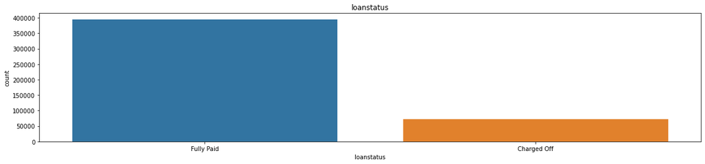

```python
# count distributions
for col in cat_feature:
    if df[col].unique().size < 100:
        plt.figure(figsize=(20, 4))
        sns.countplot(x=col, data=df).set_title(col)
    else:
        print(f'{df[col].value_counts()}\n')
```

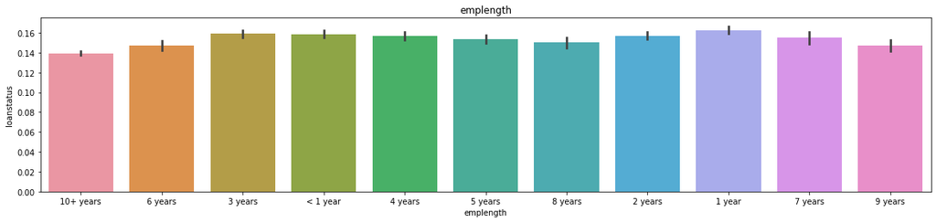

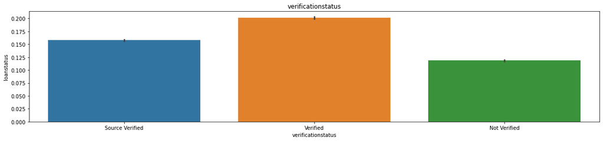

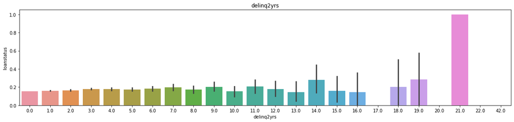

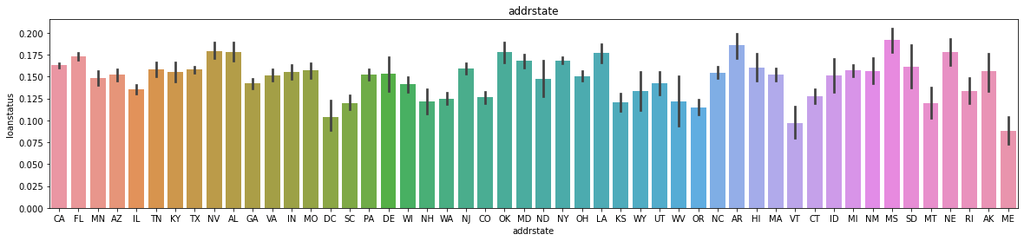

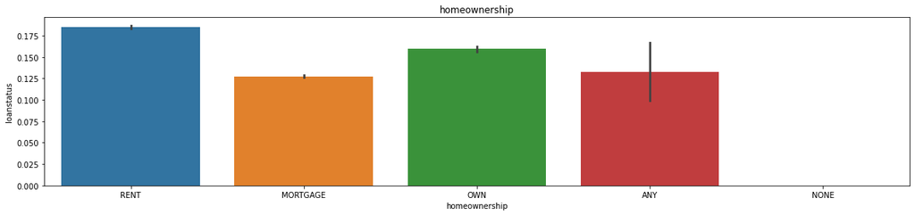

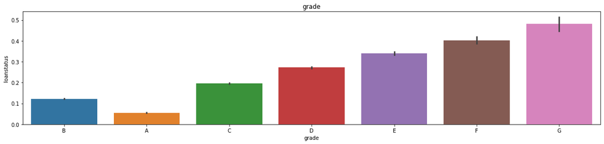

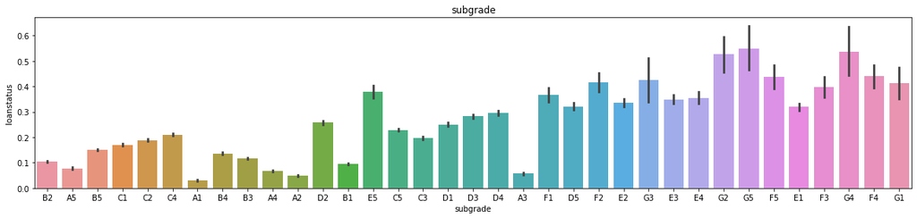

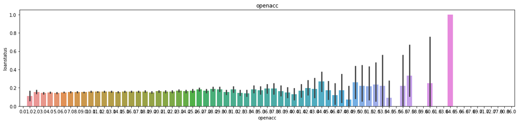

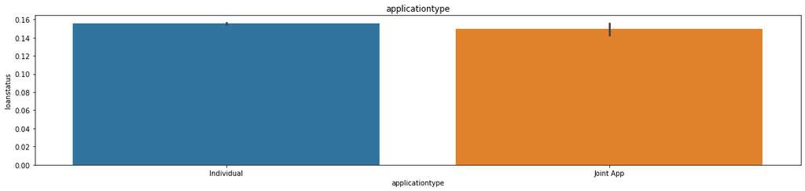

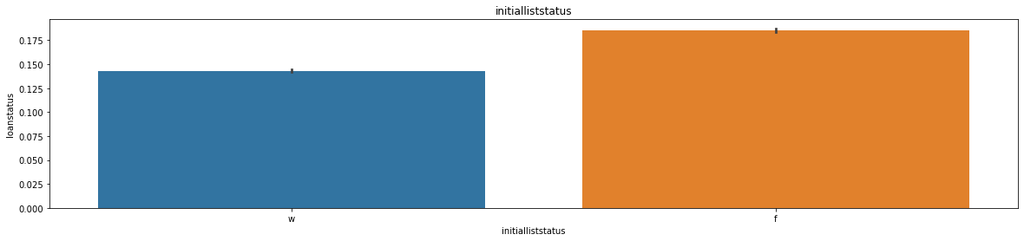

```python
# mean response on target
# encode the target
df['loanstatus'] = df['loanstatus'].map({"Charged Off" : 1, "Fully Paid" : 0})
cat_feature.remove('loanstatus')

# plot the mean response for selected categorical features
dum_feature = ['emplength', 'verificationstatus', 'delinq2yrs', 'addrstate', 'homeownership', 'grade', 'subgrade', 'openacc', 'applicationtype', 'initialliststatus']
for col in dum_feature:
    plt.figure(figsize=(20, 4))
    sns.barplot(x=col, y='loanstatus', data=df).set_title(col)
```

#### 2.3.2 Explore numerical features

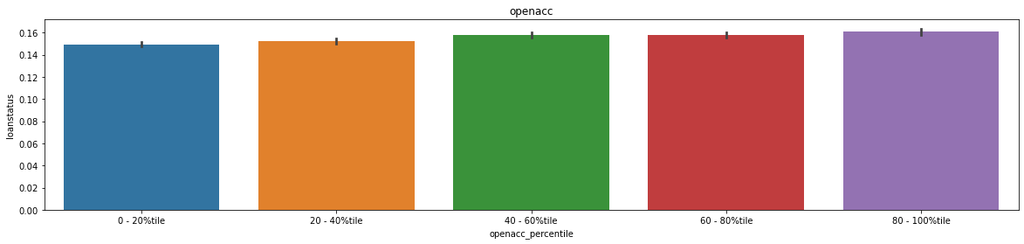

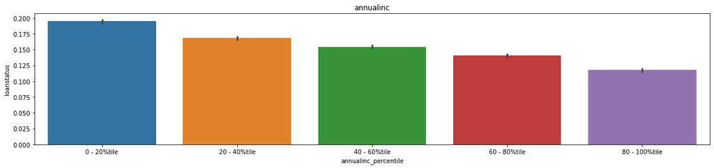

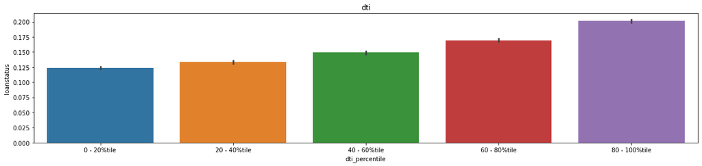

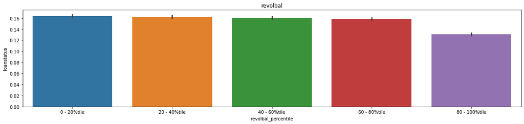

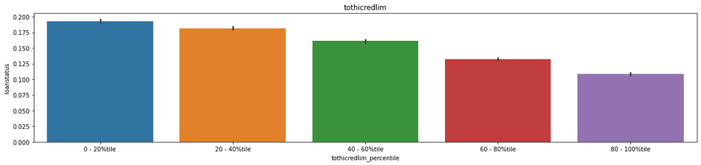

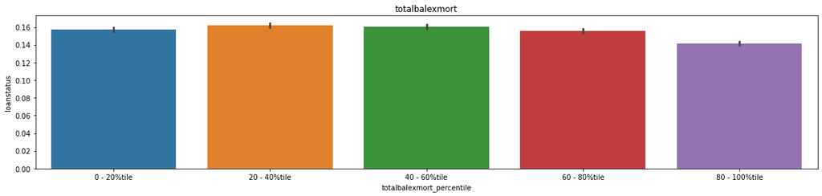

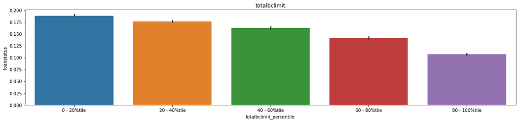

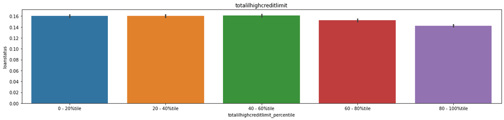

```python
# percentile mean response on target
# plot the mean response for selected numerical features
dum_feature = ['openacc', 'annualinc', 'dti', 'revolbal', 'tothicredlim', 'totalbalexmort', 'totalbclimit', 'totalilhighcreditlimit']
for col in dum_feature:
    # create the percentile features
    df[col+'_percentile'] = pd.qcut(df[col], 5, labels=['0 - 20%tile', '20 - 40%tile', '40 - 60%tile', '60 - 80%tile', '80 - 100%tile'])

    plt.figure(figsize=(20, 4))
    sns.barplot(x=col+'_percentile', y='loanstatus', data=df).set_title(col)

    # remove the percentile features
    df.drop(columns=[col+'_percentile'], inplace=True)
```

### 2.5 Feature Encoding

```python
# show categorical features
print(f"categorical features:\n{cat_feature}")
```

```
categorical features:
['zipcode', 'earliestcrline', 'emplength', 'intrate', 'verificationstatusjoint', 'subgrade', 'addrstate', 'revolutil', 'id', 'purpose', 'grade', 'applicationtype', 'verificationstatus', 'emptitle', 'initialliststatus', 'homeownership', 'issued']
```

```python
# remove useless feature: id
cat_feature.remove('id')
```

```python
# set flag for train & test splitting
# training set : 2016Q1 - 2017Q1
# test set : 2017Q2
df['test_flag'] = df['issued'].apply(lambda x : 1 if x in ['Apr-2017', 'May-2017', 'Jun-2017'] else 0)

# mark change
cat_feature.remove('issued')

# show counts
print(f"test flag:\n{df['test_flag'].value_counts()}")
```

```
test flag:
0    395418
1     72571
Name: test_flag, dtype: int64
```

```python
# earliestcrline to months
# convert to datetime
df['issued'] = df['issued'].map(lambda x : datetime.datetime.strptime(str(x), '%b-%Y'))
df['earliestcrline'] = df['earliestcrline'].map(lambda x : datetime.datetime.strptime(str(x), '%b-%Y'))

# calculate the number of months from earliestcrline to issued
df['earliestcrline_month'] = df.apply(lambda x : (x['issued'].year - x['earliestcrline'].year) * 12 + (x['issued'].month - x['earliestcrline'].month), axis=1)

# mark change
cat_feature.remove('earliestcrline')
num_feature.append('earliestcrline_month')
```

```python
# emplength to years
df['emplength'].replace('< 1 year', '0', inplace=True)
df['emplength'].replace(to_replace='[^0-9]+', value='', inplace=True, regex=True)
df['emplength'].fillna(value=-999, inplace=True)

# convert to int
df['emplength'] = df['emplength'].astype('int')

# mark change
cat_feature.remove('emplength')
num_feature.append('emplength')
```

```python
# percentage feature to numerics : intrate, revolutil
df['intrate'] = df['intrate'].apply(lambda x : str(x).replace('%','')).astype(float) / 100
df['revolutil'] = df['revolutil'].apply(lambda x : str(x).replace('%','')).astype(float) / 100

# mark change
cat_feature.remove('intrate')
num_feature.append('intrate')
cat_feature.remove('revolutil')
num_feature.append('revolutil')
```

```python
# ordinal feature encoding : grade, subgrade
df['grade'] = df['grade'].map(lambda x : ord(x) - ord('A')).astype(int)
df['subgrade'] = df['subgrade'].map(lambda x : (ord(x[0]) - ord('A')) * 5 + (ord(x[1]) - ord('1')))

# mark change
cat_feature.remove('grade')
num_feature.append('grade')
cat_feature.remove('subgrade')
num_feature.append('subgrade')
```

```python
# frequency encoding : zipcode, emptitle, addrstate
def frequency_encoder(df, col):
    dict_freq = df[col].value_counts().to_dict()
    return df[col].map(lambda x : dict_freq[x])

# zipcode
# use the first 3 numbers
df['zipcode'] = df['zipcode'].map(lambda x : str(x)[0:3] if x == x else '-999').astype(int)
df['zipcode_freq'] = frequency_encoder(df, 'zipcode')

# mark change
# keep the zipcode feature since it shows address info
cat_feature.remove('zipcode')
num_feature.append('zipcode')
num_feature.append('zipcode_freq')

# emptitle
df['emptitle'].fillna(value='nan', inplace=True)
df['emptitle_freq'] = frequency_encoder(df, 'emptitle')

# mark change
cat_feature.remove('emptitle')
num_feature.append('emptitle_freq')

# addrstate
df['addrstate'].fillna(value='NA', inplace=True)
df['addrstate_freq'] = frequency_encoder(df, 'addrstate')

# mark change
cat_feature.remove('addrstate')
num_feature.append('addrstate_freq')
```

```python
# label encoding : initialliststatus, applicationtype
from sklearn.preprocessing import LabelEncoder
le = LabelEncoder()
df['initialliststatus'] = le.fit_transform(df['initialliststatus'])
df['applicationtype'] = le.fit_transform(df['applicationtype'])

# mark change
cat_feature.remove('initialliststatus')
num_feature.append('initialliststatus')
cat_feature.remove('applicationtype')
num_feature.append('applicationtype')
```

```python
# one hot encoding : homeownership, purpose, verificationstatus & verificationstatusjoint
df_dum = pd.get_dummies(df[cat_feature])
df = pd.concat([df, df_dum], axis=1)

# mark change
cat_feature = df_dum.columns.values
```

```python
# combine encoded features
select_feature = list(num_feature) + list(cat_feature)

# show results
print(f"processed features: {len(select_feature)}\n{select_feature}")
```

```
processed features: 110
['totalilhighcreditlimit', 'numactvrevtl', 'accnowdelinq', 'mthssincelastrecord', 'ficorangelow', 'openil12m', 'mosinoldrevtlop', 'openrv12m', 'inqlast12m', 'pubrec', 'loanamnt', 'openil24m', 'ficorangehigh', 'percentbcgt75', 'annualincjoint', 'numtloppast12m', 'bcutil', 'bcopentobuy', 'tothicredlim…
```

### 2.6 Feature Correlations

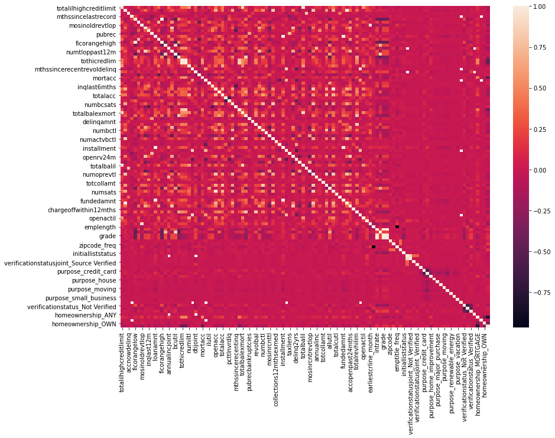

```python
# calculate correlation matrix
corr = df[select_feature].corr()

# plot heatmap
plt.figure(figsize=(14, 10))
sns.heatmap(corr)
```

```python
# check redundant faetures
corr_thres = 0.999
corr_pairs = [(corr.columns[i], corr.columns[j]) for i in range(len(corr)) for j in range(len(corr)) if i < j and np.abs(corr.iloc[i, j]) >= corr_thres]

# show results
print(f"high correlation pairs:\n{corr_pairs}")
```

```
high correlation pairs:
[('ficorangelow', 'ficorangehigh'), ('loanamnt', 'fundedamnt')]
```

```python
# loanamnt & fundedamnt
print(f"loanamnt & fundedamnt\nnumber of rows with difference: {sum(df['loanamnt'] != df['fundedamnt'])}")
```

```
loanamnt & fundedamnt
number of rows with difference: 2
```

```python
# ficorangelow & ficorangehigh
print(f"ficorangelow & ficorangehigh\nunique difference values: {list(set(df['ficorangehigh'] - df['ficorangelow']))}")
```

```
ficorangelow & ficorangehigh
unique difference values: [4.0, 5.0]
```

```python
# remove highly correlated features
# loanamnt & fundedamnt
select_feature.remove('fundedamnt')

# ficorangelow & ficorangehigh
df['ficorangemean'] = (df['ficorangelow'] + df['ficorangehigh']) / 2
select_feature.remove('ficorangelow')
select_feature.remove('ficorangehigh')
select_feature.append('ficorangemean')

# show processed features
print(f"processed features: {len(select_feature)}\n{select_feature}")
```

```
processed features: 108
['totalilhighcreditlimit', 'numactvrevtl', 'accnowdelinq', 'mthssincelastrecord', 'openil12m', 'mosinoldrevtlop', 'openrv12m', 'inqlast12m', 'pubrec', 'loanamnt', 'openil24m', 'percentbcgt75', 'annualincjoint', 'numtloppast12m', 'bcutil', 'bcopentobuy', 'tothicredlim', 'totcurbal', 'numiltl', 'mthss…
```

```python
# fill nans
df[select_feature] = df[select_feature].fillna(-999)
```

### 2.7 Sample Weight

```python
# show target counts
print(f"loanstatus:\n{df['loanstatus'].value_counts(normalize=True)}")
```

```
loanstatus:
0    0.844657
1    0.155343
Name: loanstatus, dtype: float64
```

```python
# calculate sample weight
weight_map = {k : 1 / v for k, v in df['loanstatus'].value_counts(normalize=True).iteritems()}
df['weight'] = df['loanstatus'].apply(lambda x : weight_map[x])

# show results
print(f"class weights:\n{weight_map}")
```

```
class weights:
{0: 1.183913076475499, 1: 6.437351270306332}
```

## 3. Modeling

### 3.1 Logistic Regression

```python
# training & test split
df_train = df.query('test_flag == 0')
df_train.reset_index(drop=True, inplace=True)
df_test = df.query('test_flag == 1')
df_test.reset_index(drop=True, inplace=True)
X_train, y_train, w_train = df_train[select_feature], df_train['loanstatus'], df_train['weight']
X_test, y_test, w_test = df_test[select_feature], df_test['loanstatus'], df_test['weight']

# show target counts
print(f"training set:\n{y_train.value_counts(normalize=True)}")
print(f"test set:\n{y_test.value_counts(normalize=True)}")
```

```
training set:
0    0.844112
1    0.155888
Name: loanstatus, dtype: float64
test set:
0    0.847625
1    0.152375
Name: loanstatus, dtype: float64
```

```python
# train model
from sklearn.linear_model import LogisticRegression
model_lr = LogisticRegression(solver='lbfgs', C=0.5, penalty='l2', random_state=2020, max_iter=3000, n_jobs=1, verbose=1)
model_lr.fit(X_train, y_train, sample_weight=w_train)
```

[output not shown]

```
LogisticRegression(C=0.5, class_weight=None, dual=False, fit_intercept=True,
                   intercept_scaling=1, l1_ratio=None, max_iter=3000,
                   multi_class='auto', n_jobs=1, penalty='l2',
                   random_state=2020, solver='lbfgs', tol=0.0001, verbose=1,
                   warm_start=False)
```

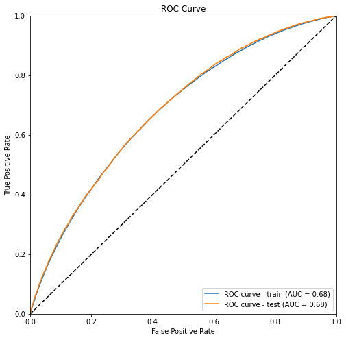

```python
# plot ROC curve
from sklearn.metrics import roc_curve, auc
def plot_roc_curve(model, X, y):
    assert(len(data) == len(y) and len(data) == 2)

    label = ['train', 'test']

    plt.figure(figsize=(8, 8))
    plt.plot([0, 1], [0, 1], 'k--')

    for i in range(len(label)):
        y_prob = model.predict_proba(X[i])[:,1]
        fpr, tpr, thresholds = roc_curve(y[i], y_prob)
        roc_auc = auc(fpr, tpr)
        plt.plot(fpr, tpr, label='ROC curve - %s (AUC = %0.2f)' % (label[i], roc_auc))

    plt.xlim([0.0, 1.0])
    plt.ylim([0.0, 1.0])
    plt.xlabel('False Positive Rate')
    plt.ylabel('True Positive Rate')
    plt.title('ROC Curve')
    plt.legend(loc="lower right")
    plt.show()

plot_roc_curve(model_lr, [X_train, X_test], [y_train, y_test])
```

```python
# calculate the feature std
df_col = pd.DataFrame(df[select_feature].std().items(), columns=['feature', 'std'])

# extract logistic regression coefficient
# divide by the std & calculate the absolute value
df_col['coef'] = model_lr.coef_.T
df_col['coef'] = df_col['coef'] / df_col['std']
df_col['abscoef'] = df_col['coef'].apply(np.abs)

# reorder the columns
df_col = df_col[['feature', 'std', 'coef', 'abscoef']]
```

### 3.2 Random Forest

```python
# train model
from sklearn.ensemble import RandomForestClassifier
model_rfc = RandomForestClassifier(criterion='gini', n_estimators=500, max_depth=10, min_samples_split=2, min_samples_leaf=1, bootstrap=True, n_jobs=4, verbose=1)
model_rfc.fit(X_train, y_train, sample_weight=w_train)
```

```
[Parallel(n_jobs=4)]: Using backend ThreadingBackend with 4 concurrent workers.
[Parallel(n_jobs=4)]: Done  42 tasks      | elapsed:   10.7s
[Parallel(n_jobs=4)]: Done 192 tasks      | elapsed:   47.5s
[Parallel(n_jobs=4)]: Done 442 tasks      | elapsed:  1.8min
[Parallel(n_jobs=4)]: Done 500 out of 500 | elapsed:  2.1min finished
```

```
RandomForestClassifier(bootstrap=True, ccp_alpha=0.0, class_weight=None,
                       criterion='gini', max_depth=10, max_features='auto',
                       max_leaf_nodes=None, max_samples=None,
                       min_impurity_decrease=0.0, min_impurity_split=None,
                       min_samples_leaf=1, min_samples_split=2,
                       min_weight_fraction_leaf=0.0, n_estimators=500, n_jobs=4,
                       oob_score=False, random_state=None, verbose=1,
                       warm_start=False)
```

```
[Parallel(n_jobs=4)]: Using backend ThreadingBackend with 4 concurrent workers.
[Parallel(n_jobs=4)]: Done  42 tasks      | elapsed:    0.6s
[Parallel(n_jobs=4)]: Done 192 tasks      | elapsed:    2.7s
[Parallel(n_jobs=4)]: Done 442 tasks      | elapsed:    6.3s
[Parallel(n_jobs=4)]: Done 500 out of 500 | elapsed:    7.1s finished
[Parallel(n_jobs=4)]: Using backend ThreadingBackend with 4 concurrent workers.
[Parallel(n_jobs=4)]: Done  42 tasks      | elapsed:    0.1s
[Parallel(n_jobs=4)]: Done 192 tasks      | elapsed:    0.5s
[Parallel(n_jobs=4)]: Done 442 tasks      | elapsed:    1.1s
[Parallel(n_jobs=4)]: Done 500 out of 500 | elapsed:    1.2s finished
```

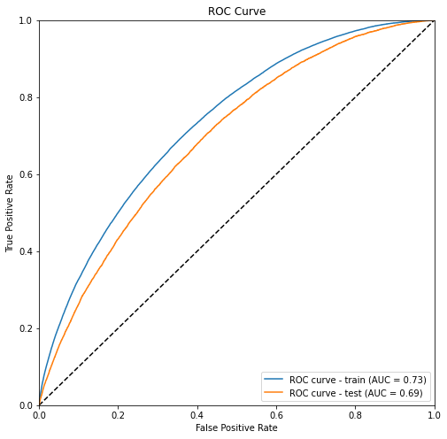

```python
# plot ROC curve
plot_roc_curve(model_rfc, [X_train, X_test], [y_train, y_test])
```

### 3.3 XGBoost Model

```python
# training & test split
df_train = df.query('test_flag == 0')
df_train.reset_index(drop=True, inplace=True)
df_test = df.query('test_flag == 1')
df_test.reset_index(drop=True, inplace=True)
X_test, y_test = df_test[select_feature], df_test['loanstatus']

# training & validation split
from sklearn.model_selection import train_test_split
X_train, X_valid, y_train, y_valid = train_test_split(df_train[select_feature], df_train['loanstatus'], test_size=0.3, random_state=2020, stratify=df_train['loanstatus'])
```

```python
# data conversion
import xgboost as xgb
data_train = xgb.DMatrix(X_train, y_train)
data_valid = xgb.DMatrix(X_valid, y_valid)
data_test = xgb.DMatrix(X_test, y_test)
```

```python
# set parameter
params = {
    "booster"           : "gbtree",
    "objective"         : "binary:logistic",
    "eval_metric"       : "auc",
    "eta"               : 0.015,
    "gamma"             : 0.18,
    "max_depth"         : 5,
    "min_child_weight"  : 15,
    "subsample"         : 0.7,
    "colsample_bytree"  : 0.25,
    "silent"            : 1,
    "seed"              : 2020,
    "scale_pos_weight"  : 1,
    "scale_pos_weight"  : weight_map[1] / weight_map[0],
}

# train model
model_xgb = xgb.train(params, data_train, 3000, evals=[(data_train, 'train'), (data_valid, 'eval')], verbose_eval=100, early_stopping_rounds=50)
```

[output not shown]

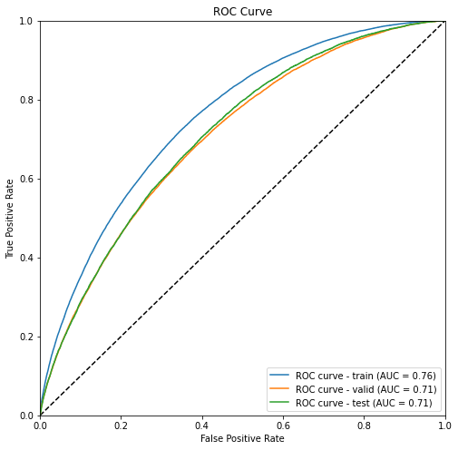

```python
# plot ROC curve
def plot_roc_curve(model, data, y):
    assert(len(data) == len(y) and len(data) == 3)

    label = ['train', 'valid', 'test']

    plt.figure(figsize=(8, 8))
    plt.plot([0, 1], [0, 1], 'k--')

    for i in range(len(label)):
        y_prob = model.predict(data[i], ntree_limit=model.best_ntree_limit)
        fpr, tpr, thresholds = roc_curve(y[i], y_prob)
        roc_auc = auc(fpr, tpr)
        plt.plot(fpr, tpr, label='ROC curve - %s (AUC = %0.2f)' % (label[i], roc_auc))

    plt.xlim([0.0, 1.0])
    plt.ylim([0.0, 1.0])
    plt.xlabel('False Positive Rate')
    plt.ylabel('True Positive Rate')
    plt.title('ROC Curve')
    plt.legend(loc="lower right")
    plt.show()

plot_roc_curve(model_xgb, [data_train, data_valid, data_test], [y_train, y_valid, y_test])
```

```python
# extract feature importance from XGBoost model
df_col = df_col.merge(pd.DataFrame(model_xgb.get_fscore().items(), columns=['feature', 'fscore']), on='feature', how='outer')
df_col['fscore'] = df_col['fscore'] / df_col['fscore'].sum()

# add feature description
df_col['description'] = df_col['feature'].apply(lambda x : desc_hist.get(x.split('_')[0], '')).values

# sort by the absolute value of logistic regression coefficient
df_col = df_col.sort_values(by=['abscoef'], ascending=False)
df_col.reset_index(drop=True, inplace=True)

# show results
df_col.head(10)
```

|  | feature | std | coef | abscoef | fscore | description |
| --- | --- | --- | --- | --- | --- | --- |
| 0 | subgrade | 5.480828 | 0.000427 | 0.000427 | 0.015262 | LC assigned loan subgrade |
| 1 | intrate | 0.043507 | 0.000423 | 0.000423 | 0.019579 | Interest Rate on the loan |
| 2 | grade | 1.091206 | 0.000417 | 0.000417 | 0.006447 | LC assigned loan grade |
| 3 | accopenpast24mths | 3.273961 | 0.000246 | 0.000246 | 0.011202 | Number of trades opened in past 24 months. |
| 4 | numtloppast12m | 1.912671 | 0.000228 | 0.000228 | 0.005054 | Number of accounts opened in past 12 months |
| 5 | inqlast6mths | 0.847447 | 0.000178 | 0.000178 | 0.004537 | The number of inquiries in past 6 months (excluding auto and mortgage inquiries) |
| 6 | verificationstatus_Not Verified | 0.470675 | -0.000125 | 0.000125 | 0.002626 | Indicates if income was verified by LC, not verified, or if the income source was verified |
| 7 | verificationstatus_Verified | 0.426225 | 0.000115 | 0.000115 | 0.001990 | Indicates if income was verified by LC, not verified, or if the income source was verified |
| 8 | numrevtlbalgt0 | 3.286321 | 0.000114 | 0.000114 | 0.006885 | Number of revolving trades with balance >0 |
| 9 | numactvrevtl | 3.405347 | 0.000108 | 0.000108 | 0.007919 | Number of currently active revolving trades |

### 3.4 Results

- XGBoost has the highest AUC score, benefited from the gradient boosting algorithm, however, the model interpretability of XGBoost is not so good. The extracted fscore can only qualitatively show the feature importance, which is much less accurate as the Logistic Regression coefficients.
- Logistic Regression has the lowest AUC score due to its linearity, however, the fitted coefficients can quantitatively show how the target changes as a function of all the features.
  - Lending Club's loan grade and subgrade; interest rate; number of trades opened in past 24 months, number of accounts opened in past 12 months and number of inquiries in past 6 months have strong positive influence on the charge off rate.
  - Income was not verified by LC has strong negative influence on the charge off rate. This is counterintuitive, maybe due to the fact that income was not verified, the other screening process may be more strict and the loan amount will be limited.
- Random Forest has an intermediate AUC score, while its model interpretability is similar as XGBoost.

## 4. Summary

- We use Logistic Regression, Random Forest and XGBoost to predict the charge off probability of the loan data in LendingClub, achieving a best AUC score of 0.71.
- From both EDA and Logistic Regression, we find some features with strong predicting power: Lending Club's loan grade and subgrade; interest rate; number of trades opened in past 24 months, number of accounts opened in past 12 months and number of inquiries in past 6 months.
- The model can be used to predict the default rate on newly listed loans in Lending Club, and an automated trading strategy can be build on it.
- However, the automated LendingClub trading strategy may not be very profitable. The interest rate for the Grade A loan is 8.46 - 10.81%, which is lower than the long term annual term of S&P 500, which is more than 10% including the dividend yield. Therefore, in order to make more profit on the strategy, we need to pick the relatively low risk loans in Grade B, C & D, which will have higher interest rates.